# 빅데이터 분석 기사 예제 문제 풀이

doyeon

2021 5 5

```r
library(data.table) #fread()
library(skimr) #EDA
library(forecast)
library(caret)
library(tidymodels)
library(gridExtra) #grid.arrange
library(glmnet)
theme_set(theme_bw())
```

###과제1.  
#Data import

```r
data <- fread("C:/R/workspace/project/study/day01/mtcars.csv",header = T)
```

1. min-max(normalization)  
   :모든 feature가 0과 1사이에 위치하게 만듭니다. 데이터가 2차원 셋일 경우, 모든 데이터는 x축의 0과 1 사이에, y축의 0과 1사이에 위치하게 됩니다.

```r
data$qsec <- scale(data$qsec,center = min(data$qsec),scale = max(data$qsec)-min(data$qsec))
data %>%
    filter(mtcars>0.5) %>%
    tally()
```

```
##    n
## 1 32
```

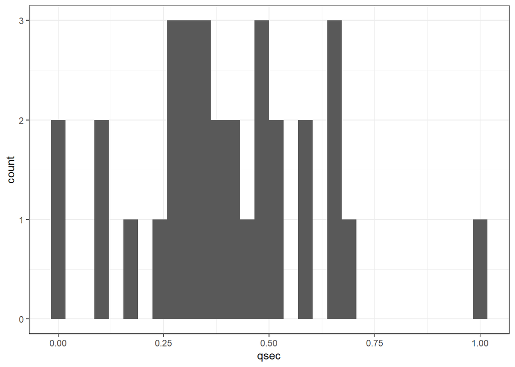

```r
ggplot(data,aes(qsec))+
    geom_histogram()
```

2. standardization  
   :각 feature의 평균을 0, 분산을 1로 변경합니다. 모든 특성들이 같은 스케일을 갖게 됩니다.

```r
data$qsec = scale(data$qsec,center = T,scale = T)
data %>%
    filter(mtcars>0.5) %>%
    tally()
```

```
##    n
## 1 32
```

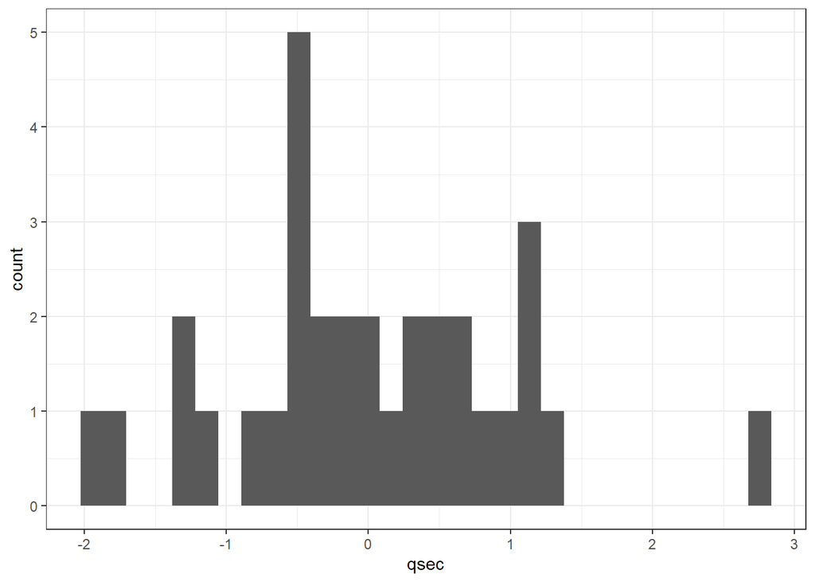

```r
ggplot(data,aes(qsec))+
    geom_histogram()
```

3)Robust scale  
:모든 특성들이 같은 크기를 갖는다는 점에서 StandardScaler와 비슷하지만, 평균과 분산 대신 median과 quartile을 사용합니다. RobustScaler는 이상치에 영향을 받지 않습니다.

```r
data$qsec <- DescTools::RobScale(data$qsec, center = TRUE, scale = TRUE)
data %>%
    filter(mtcars>0.5) %>%
    tally()
```

```
##    n
## 1 32
```

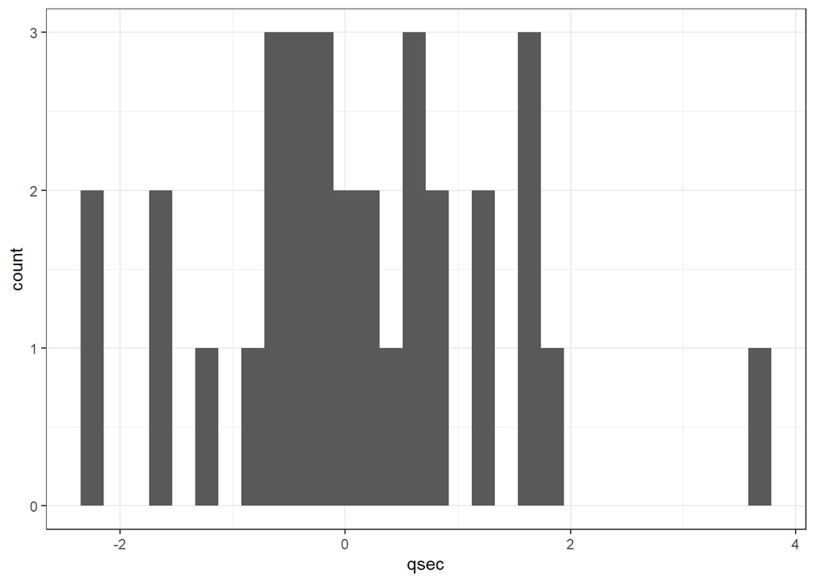

```r
ggplot(data,aes(qsec))+
    geom_histogram()
```

###과제2.

#Import Data

```r
x_train <- fread("C:/R/workspace/project/X_train.csv",header = T,stringsAsFactors = T)
y_train <- fread("C:/R/workspace/project/y_train.csv",header = T,stringsAsFactors = T)
#x_test <- fread("C:/R/workspace/project/X_test.csv",header = T,stringsAsFactors = T)

all_data <- x_train %>%
    bind_cols(y_train %>% select(gender))

all_data %>% skim()
#dim(3500,11)
```

#preprocessing data

```r
all_data <- all_data %>%
    select(-cust_id)

#총구매액 변수 타입에 대한 이슈 발생
all_data <- all_data %>%
    mutate(총구매액 = factor(총구매액)) %>%
    mutate(총구매액 = as.integer(총구매액))

#환불금액의 NA값 0으로 대체 > 환불이 없었다면 금액 환산시 0이므로
all_data <- all_data %>%
    mutate(환불금액 = ifelse(is.na(환불금액),0,환불금액))

#factor 변환
all_data <- all_data %>%
    mutate(gender = factor(gender))
```

#preprocessing2 - Recipe

```r
recipe <- all_data %>%
    recipe(gender ~.) %>%
    step_integer(all_nominal(),-all_outcomes()) %>%
    step_scale(all_numeric(),-all_outcomes()) %>%
    prep(training = all_data)
all_data2 <- juice(recipe)
```

#EDA

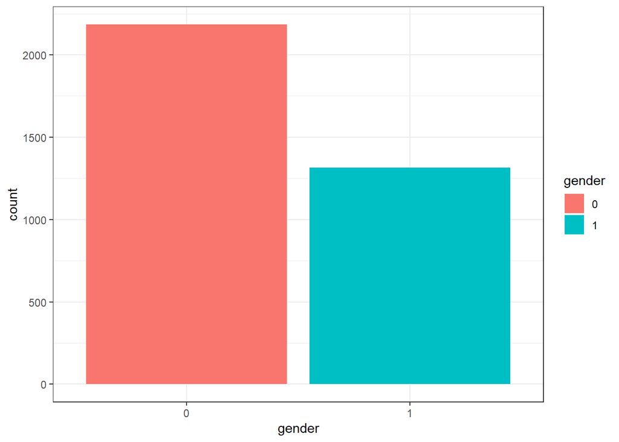

```r
#Target variable
ggplot(all_data,aes(x=gender,fill = gender))+
    geom_bar()
```

1)총구매액

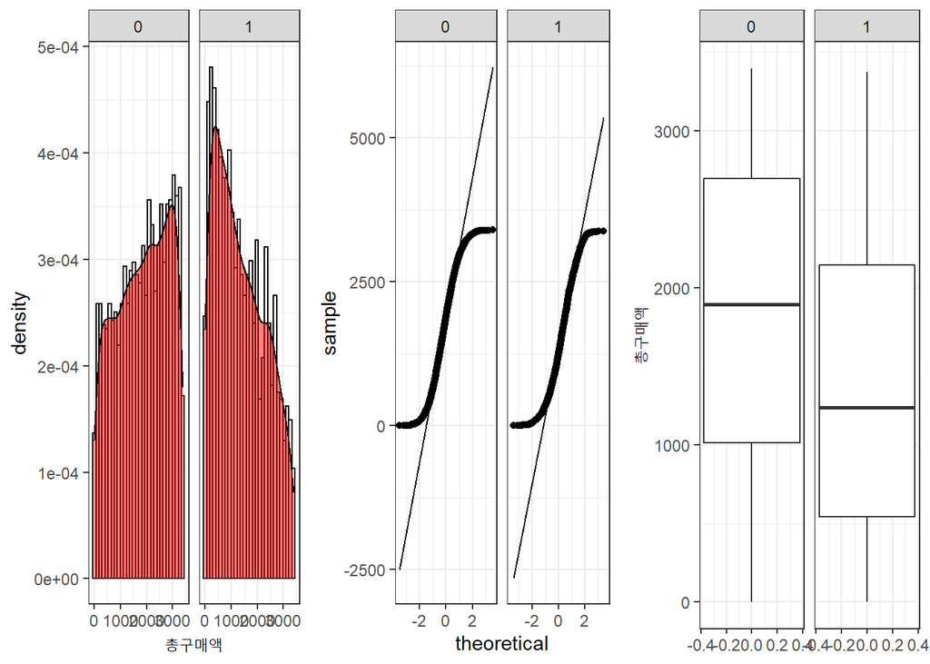

```r
g1 <- ggplot(all_data,aes(x = 총구매액))+
    geom_histogram(aes(y=..density..), colour="black", fill="white")+
    geom_density(alpha=.5, fill="red")+
    facet_grid(~gender)

g2 <- ggplot(all_data,aes(sample = 총구매액))+
    stat_qq()+
    stat_qq_line()+
    facet_grid(~gender)

g3 <- ggplot(all_data,aes(x = 총구매액))+
    geom_boxplot()+
    coord_flip()+
    facet_grid(~gender)

grid.arrange(g1,g2,g3,nrow = 1,ncol = 3)
```

```r
#shapiro.test(all_data$총구매액) #정규성검정
```

1-2)로그 변환

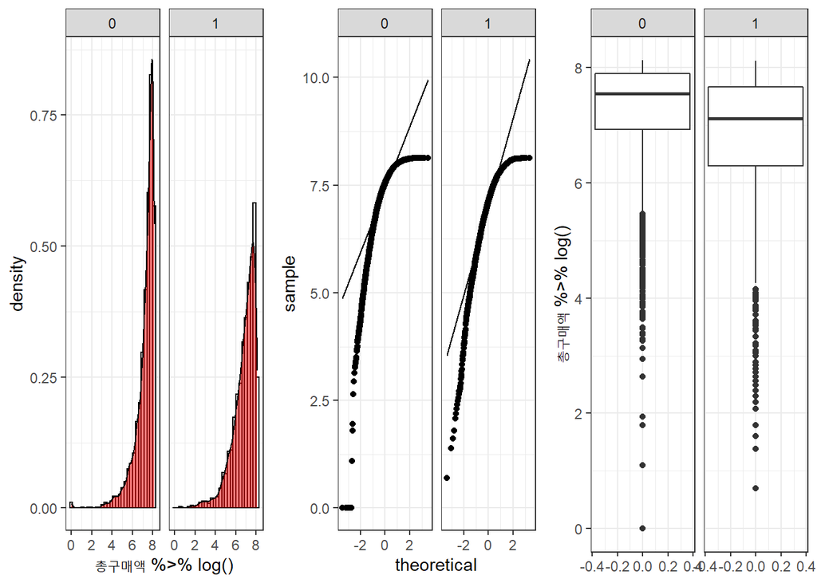

```r
g4 <- ggplot(all_data,aes(x = 총구매액 %>% log()))+
    geom_histogram(aes(y=..density..), colour="black", fill="white")+
    geom_density(alpha=.5, fill="red")+
    facet_grid(~gender)

g5 <- ggplot(all_data,aes(sample = 총구매액 %>% log()))+
    stat_qq()+
    stat_qq_line()+
    facet_grid(~gender)

g6 <- ggplot(all_data,aes(x = 총구매액 %>% log()))+
    geom_boxplot()+
    coord_flip()+
    facet_grid(~gender)

grid.arrange(g4,g5,g6,nrow = 1,ncol = 3)
```

2-1)최대구매액

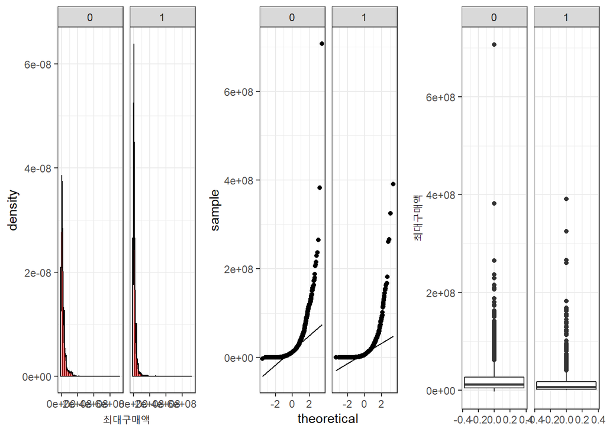

2-2)log transformation

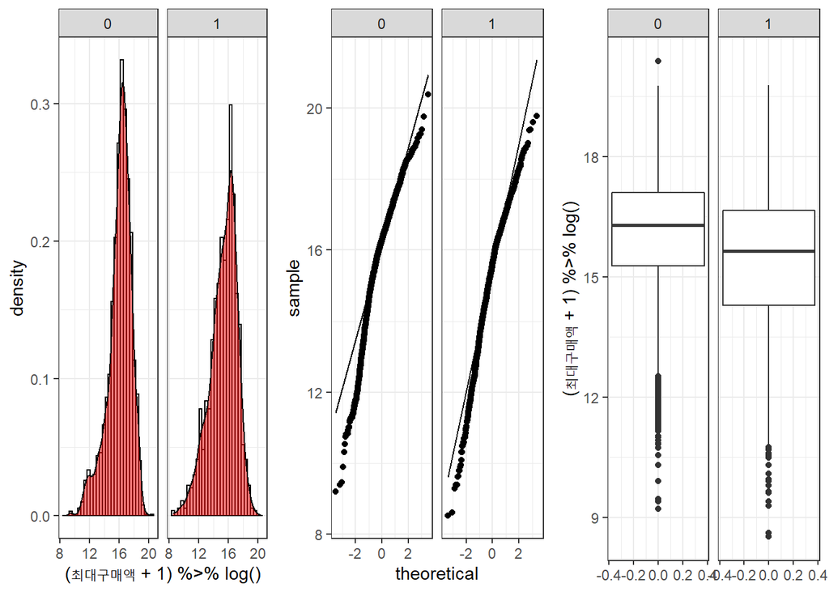

3-1)환불금액

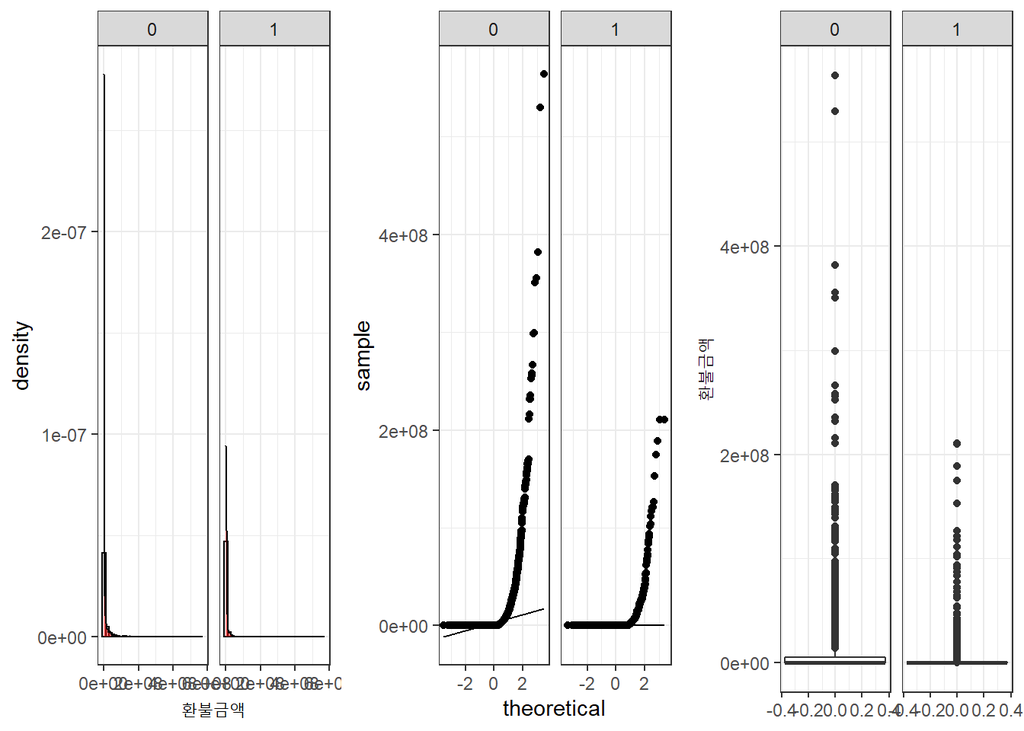

3-2)log transformation

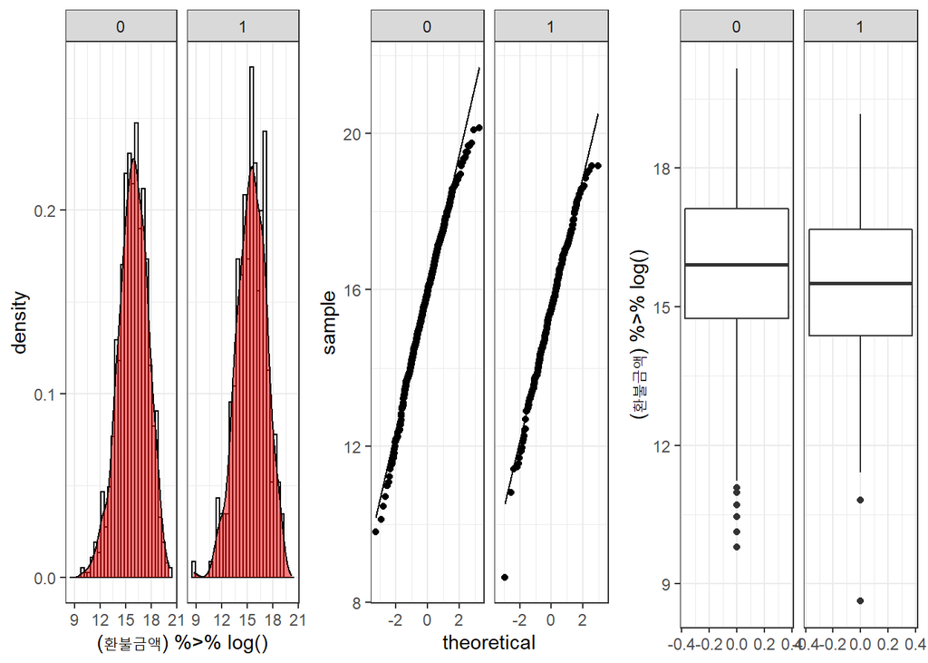

4)내점당구매건수

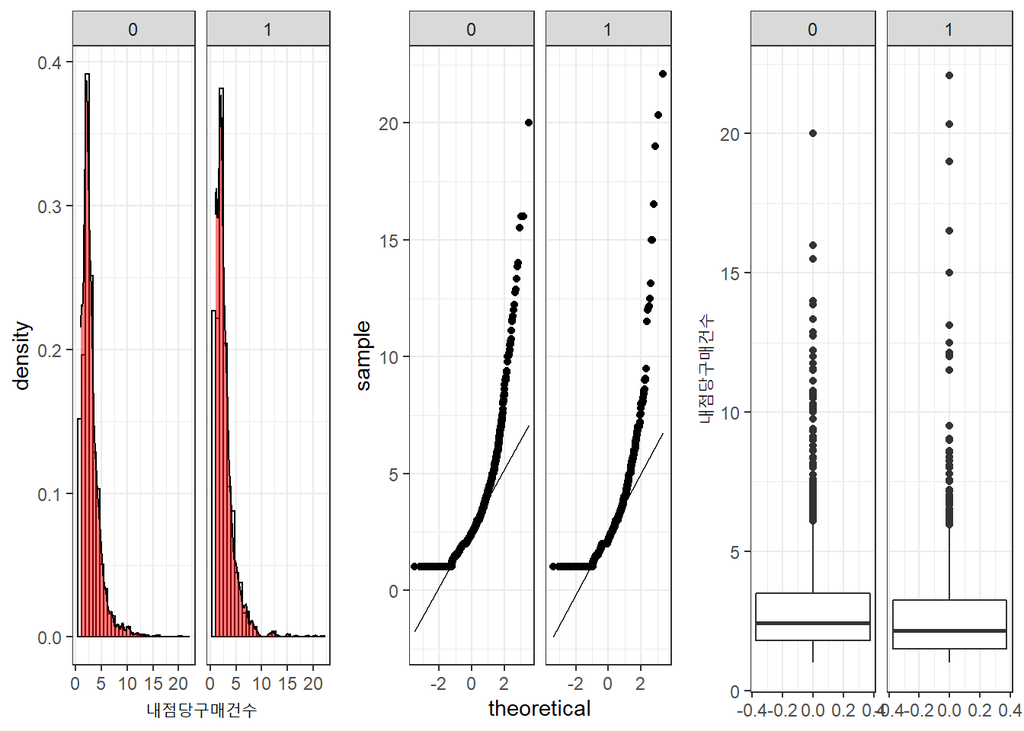

4-2)log transformation

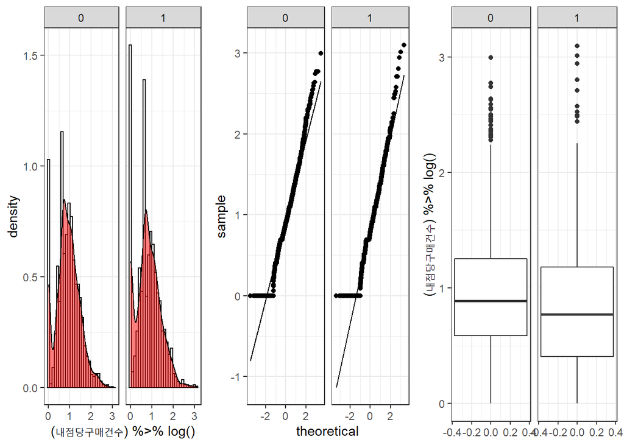

5)주말방문비율

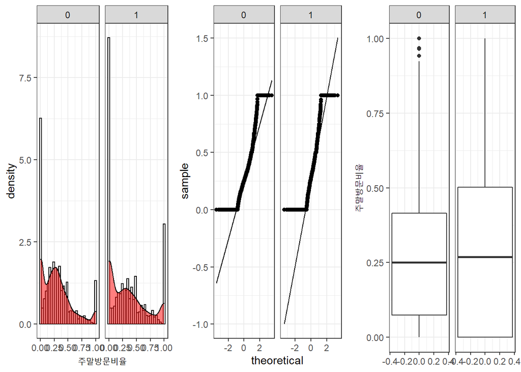

5-2)log

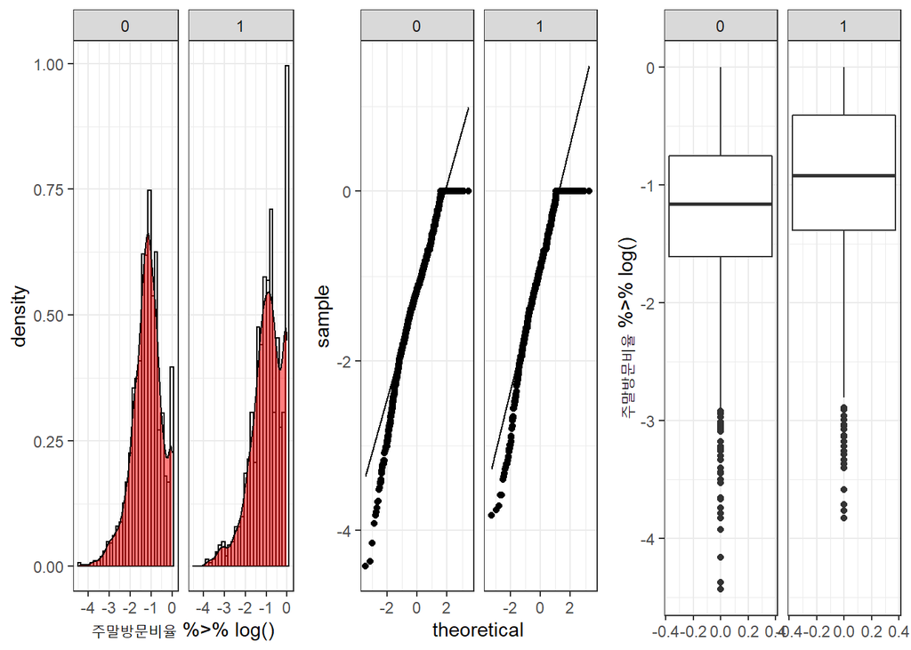

6)내점일수

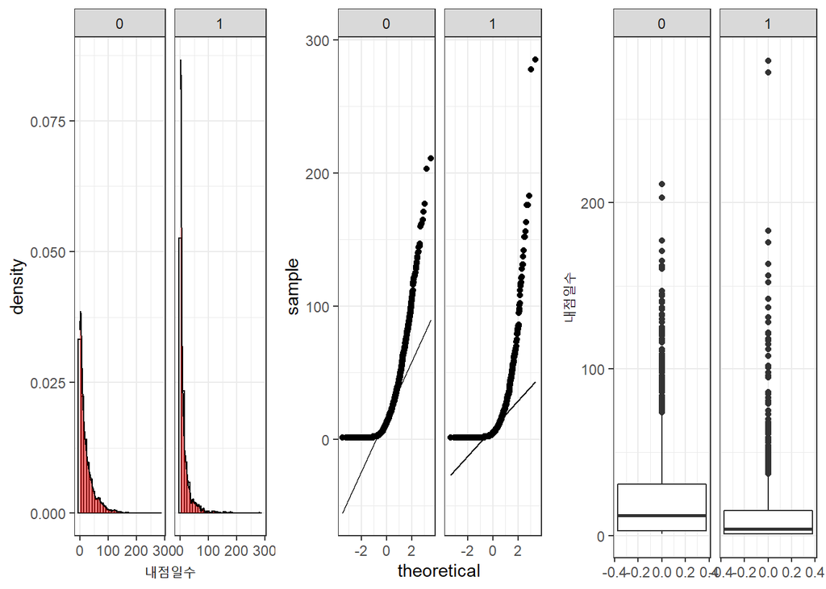

6-2)log

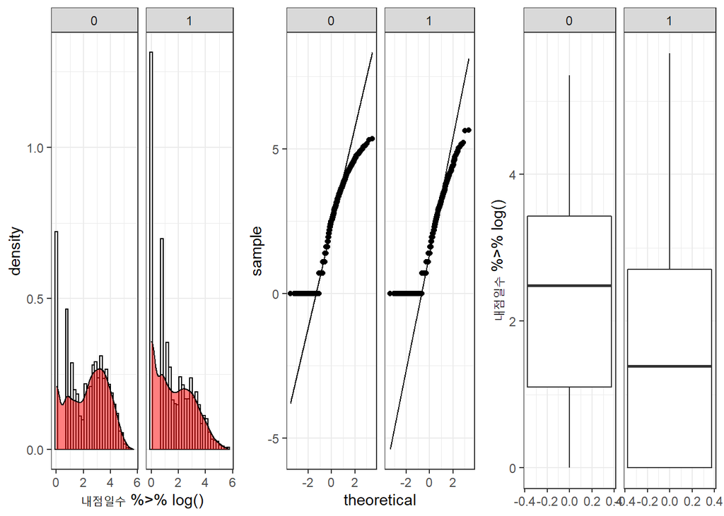

#Mosaic plot

```r
char_var <- all_data %>%
    select_if(is.factor)
char_var
```

```
##        주구매상품 주구매지점 gender
##    1:        기타     강남점      0
##    2:      스포츠     잠실점      0
##    3: 남성 캐주얼     관악점      1
##    4:        기타     광주점      1
##    5:        보석     본  점      0
##   ---
## 3496:        골프     본  점      1
## 3497:    시티웨어   부산본점      1
## 3498:    주방용품     창원점      0
## 3499:      화장품     본  점      0
## 3500:        기타     본  점      0
```